# Introduction to Statistics and Data Science: Instructor’s Guide - Day 05

Today’s lesson covers [Section 2.7 - 2.9](https://nustat.github.io/intro-stat-data-sci/02-visualization.html) and focuses on making boxplots and barplots with `ggplot()`.

**Agenda**

~ 15 min Slide deck

~ 25 min Students work on Activity 04

~ 10 min Work through a select problem in detail from the activity as a class

## Slide Deck

**Today’s goals**

1. Create a boxplot
2. Create a barplot
3. Properly describe a boxplot and barplot
4. Display barplots in various ways by category

[figure not shown]

Artwork by @allison_horst

**5NG#4: Boxplots**

- A boxplot is used to visualize the **distribution** of a single **numerical** variable.
- Grouped boxplots are particularly useful for comparing the distribution of a numerical variable across a **categorical** variable. ie: shows the relationship between a numerical and a categorical variable.

**Boxplot syntax in R:**

```r
ggplot(data= my_data, aes(x = (optional categorical variable),  y = var1)) +
  geom_boxplot()
```

If you switch x and y, it will just change the orientation of the boxplot (personal preference).

**5NG#4: Boxplots**

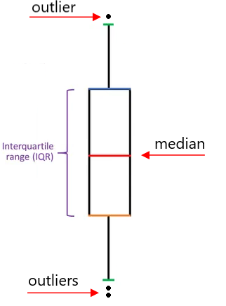

There are 3 things that we typically focus on and describe/compare when inspecting a boxplot:

- center
- spread
- shape and outliers

Is `Survived` a categorical or numerical variable?

- It should be categorical even though it is coded as numerical “dbl”

[figure not shown]

**Binary Variables**

Consider the `titanic` dataset, which contains information about passengers on the titanic. If a passenger survived, then the variable `Survived = 1`.

````markdown
```{r}

titanic %>%
  select(PassengerId, Survived, Sex) %>%
  glimpse()
```
````

```
Rows: 418
Columns: 3
$ PassengerId <dbl> 892, 893, 894, 895, 896, 897, 898, 899, 900, 901, 902, 903~
$ Survived    <dbl> 0, 1, 0, 0, 1, 0, 1, 0, 1, 0, 0, 0, 1, 0, 1, 1, 0, 0, 1, 1~
$ Sex         <chr> "male", "female", "male", "male", "female", "male", "femal~
```

Is `Survived` a categorical or numerical variable?

`R` will read in numerical columns as “numbers” even though these numbers are supposed to represent “categories”.

To fix this we need to use the `factor()` function.

Typing `factor(Survived)` would turn the variable into a “factor”.

**5NG#5: Barplots**

A barplot is used to visualize the distribution (frequencies) of a single categorical variable.

- `geom_bar()` is used when we have the raw data and counting how many observations are in each category has to be done (list not yet counted).
- `geom_col()` is used when we directly have counts of each category in our dataset (pre-counted).

**Barplot syntax in R:**

```r
ggplot(data= my_data, aes(x = var1)) +
  geom_bar()
```

**5NG#5: Barplots continued**

When describing a barplot we look for…

- Disparities in the height of the bars.
- Bar with the most observations.
- Bar with the least observations.
- If all the bars are about equal height, then the distribution is uniform.

Are we using `geom_bar()` or `geom_col()`?

- `geom_bar()`

[figure not shown]

**Example 1: Barplots**

Consider the Palmer Penguins dataset.

````markdown
```{r}

library(palmerpenguins)
head(penguins)
```
````

```
# A tibble: 6 x 8
  species island    bill_length_mm bill_depth_mm flipper_l~1 body_~2 sex    year
  <fct>   <fct>              <dbl>         <dbl>       <int>   <int> <fct> <int>
1 Adelie  Torgersen           39.1          18.7         181    3750 male   2007
2 Adelie  Torgersen           39.5          17.4         186    3800 fema~  2007
3 Adelie  Torgersen           40.3          18           195    3250 fema~  2007
4 Adelie  Torgersen           NA            NA            NA      NA <NA>   2007
5 Adelie  Torgersen           36.7          19.3         193    3450 fema~  2007
6 Adelie  Torgersen           39.3          20.6         190    3650 male   2007
# ... with abbreviated variable names 1: flipper_length_mm, 2: body_mass_g
```

We are interested in plotting the distribution of `species`.

Are we using `geom_bar()` or `geom_col()`?

What would pre-counted data look like?

**Data**

````markdown
```{r}

penguins_counted
```
````

```
# A tibble: 3 x 2
  species       n
  <fct>     <int>
1 Adelie      152
2 Chinstrap    68
3 Gentoo      124
```

**Code**

````markdown
```{r}

penguins_counted <- penguins %>%
  count(species)
```
````

**Teaching note:**

- stacked: best if you are interested in overall counts but difficult to visually see if there is a difference between categories because of the **different counts**
- proportion: best if you are interested in the **rate** within each category. Not concerned with counts.
- side-by-side: best if you want to see differences between categories but still want to see the count discrepancies between the main category

**Example 2: Barplots**

What if we want to visualize the distribution of `sex` in each of the `species`. There are 4 main ways to visualize multiple levels within a categorical data:

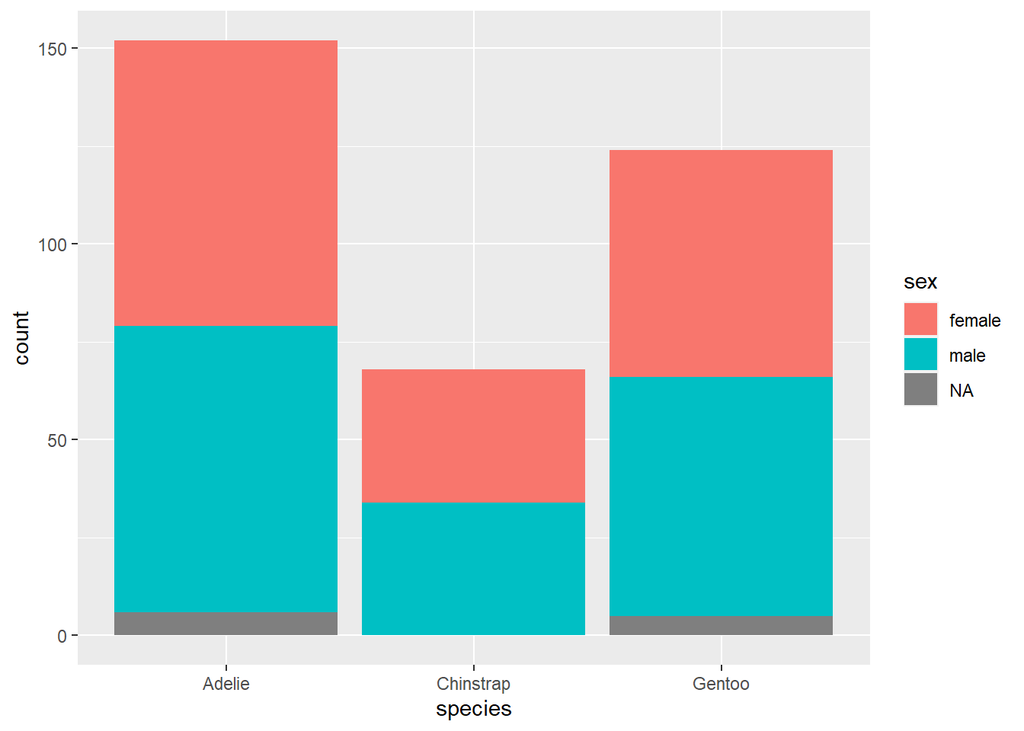

```r
ggplot(data=penguins, aes(x = species, fill = sex)) +
  geom_bar()
```

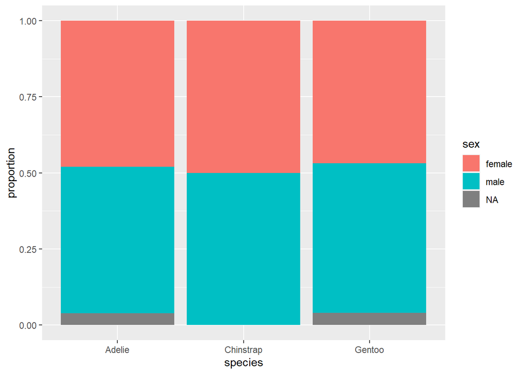

```r
ggplot(data=penguins, aes(x = species, fill = sex)) +
  geom_bar(position = "fill") +
  ylab("proportion")
```

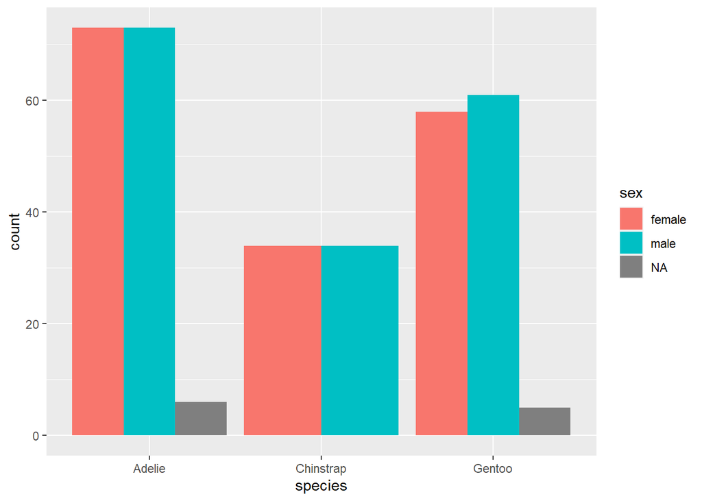

```r
ggplot(data=penguins, aes(x = species, fill = sex)) +
  geom_bar(position = "dodge")
```

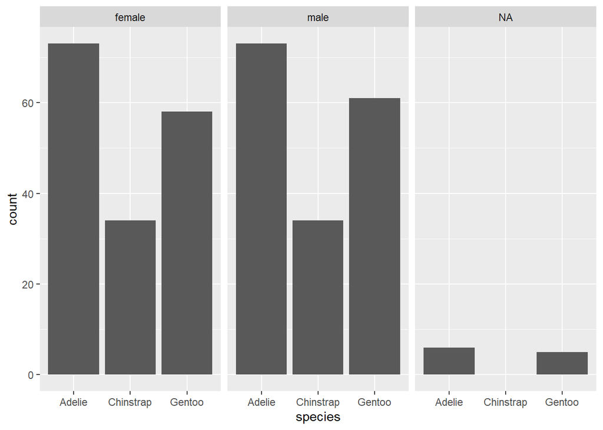

```r
ggplot(data=penguins, aes(x = species))+
  geom_bar() +
  facet_wrap(~ sex)
```

**Extra information and resources**

**“factor” vs “character” variable**

- factor has predefined levels and the observation must be one of those levels (limited response options).
- character can take on any string value (think open response options)
- [Factors in R](https://www.stat.berkeley.edu/~s133/factors.html)

## Homework

- Complete and submit Activity 04
- Read Sections 3.0 - 3.3 of the book
- Complete and submit Reading Check 05_wrangling1